# Lab 9: Statistics

Regressions, Tables, Coefficient plots, Residuals

Author

Bogdan G. Popescu

```r
#Removing previous datasets in memory
rm(list = ls())
#Loading the relevant libraries
library(ggplot2)
library(gridExtra)
library(dplyr)
library(purrr)
library(sf)
library(rnaturalearth)
library(rnaturalearthdata)
library(ggrepel)
library(modelsummary)
library(broom)
library(gganimate)
```

# 1 Intro

In this lab, we learn about running regressions, interpreting regression coeffcients, making nice tables, and making coefficient plots.

# 2 Loading the Data

Let us go back to the old Life Expectancy and urbanization datasets. If you don’t have them anymore, you can download them from the following links:

- [Life expectancy data](https://www.dropbox.com/s/8tgabpg3j7cktc1/life-expectancy.csv?dl=0)
- [Urbanization data](https://www.dropbox.com/s/koh4815kibfbroy/share-of-population-urban.csv?dl=0)

```r
#Setting path
setwd("/Users/bgpopescu/Dropbox/john_cabot/teaching/stats/lab9/")
#Step1: Loading the data
life_expectancy_df <- read.csv(file = './life-expectancy.csv')
urbanization_df <- read.csv(file = './share-of-population-urban.csv')
```

# 3 Cleaning the Data

In the next few lines we average life expectancy over country (the original dataset is a panel - with countries and years). This means that we are getting rid of the time component.

```r
#Step1: Selecting after 1900
life_expectancy_df<-subset(life_expectancy_df, Year>1900)
#Step2: Calculating the mean
life_expectancy_df2<-life_expectancy_df%>%
  dplyr::group_by(Entity, Code)%>%
  dplyr::summarize(life_exp_mean=mean(Life.expectancy.at.birth..historical.))
#Step3: Cleaning the Data
weird_labels <- c("OWID_KOS", "OWID_WRL", "")
clean_life_expectancy_df<-subset(life_expectancy_df2, !(Code %in% weird_labels))
head(clean_life_expectancy_df, n=5)
```

| Entity | Code | life_exp_mean |
| --- | --- | --- |
| Afghanistan | AFG | 45.38333 |
| Albania | ALB | 68.28611 |
| Algeria | DZA | 57.53013 |
| American Samoa | ASM | 68.63750 |
| Andorra | AND | 77.04861 |

```r
#Step1: Calculating the mean
urbanization_df2<-urbanization_df%>%
  dplyr::group_by(Code)%>%
  dplyr::summarize(urb_mean=mean(Urban.population....of.total.population.))
#Step2: Cleaning the Data
weird_labels <- c("OWID_KOS", "OWID_WRL", "")
clean_urbanization_df<-subset(urbanization_df2, !(Code %in% weird_labels))
head(clean_urbanization_df, n=5)
```

| Code | urb_mean |
| --- | --- |
| ABW | 48.05939 |
| AFG | 18.61175 |
| AGO | 37.53970 |
| ALB | 40.44416 |
| AND | 87.04302 |

We can now left merge urbanization on life expectancy

```r
#Step1: Performing the left_merge
merged_data<-left_join(clean_life_expectancy_df, clean_urbanization_df, by = c("Code"="Code"))
#Step2: Getting rid of the NAs
merged_data2<-subset(na.omit(merged_data))
#Step3: Sorting by Entity name
merged_data2 <- merged_data2[order(merged_data2$Entity),]
glimpse(merged_data2)
```

```
Rows: 214
Columns: 4
Groups: Entity [214]
$ Entity        <chr> "Afghanistan", "Albania", "Algeria", "American Samoa", "…
$ Code          <chr> "AFG", "ALB", "DZA", "ASM", "AND", "AGO", "ATG", "ARG", …
$ life_exp_mean <dbl> 45.38333, 68.28611, 57.53013, 68.63750, 77.04861, 45.084…
$ urb_mean      <dbl> 18.61175, 40.44416, 52.60921, 79.76249, 87.04302, 37.539…
```

Let us now calculate the correlation between life expectancy and urbanization using the two ways we learned.

# 4 Correlation between urbanization and life expectancy

As we discussed in the previous lab, we can calculate correlations using the `cor` command. This is given by the following formula:

$$\rho = r = \frac{\frac{\Sigma(X_{i} - \bar{X}) (Y_i - \bar{Y})}{n}}{s_X * s_Y}$$

```r
cor_coeff<-cor(merged_data2$urb_mean, merged_data2$life_exp_mean, method = c("pearson"))
cor_coeff
```

```
[1] 0.6906849
```

We can use the correlation coefficient to calculate the b, following the formula:

$$b = r \frac{s_Y}{s_X}$$

```r
b_res<-cor_coeff*(sd(merged_data2$life_exp_mean)/sd(merged_data2$urb_mean))
b_res
```

```
[1] 0.2515915
```

We can also obtain the same result by running a regression

```r
model<-lm(life_exp_mean~urb_mean, data=merged_data2)
summary(model)
```

```
Call:
lm(formula = life_exp_mean ~ urb_mean, data = merged_data2)

Residuals:
    Min      1Q  Median      3Q     Max
-14.371  -3.929  -0.529   4.562  18.623

Coefficients:
            Estimate Std. Error t value Pr(>|t|)
(Intercept) 48.96112    1.02706   47.67   <2e-16 ***
urb_mean     0.25159    0.01809   13.91   <2e-16 ***
---
Signif. codes:  0 '***' 0.001 '**' 0.01 '*' 0.05 '.' 0.1 ' ' 1

Residual standard error: 6.398 on 212 degrees of freedom
Multiple R-squared:  0.477, Adjusted R-squared:  0.4746
F-statistic: 193.4 on 1 and 212 DF,  p-value: < 2.2e-16
```

The way we interpret b is the following: every unit increase in urbanization is associated with an increase in life expectancy of 0.25. This effect is highly statistically significant.

# 5 Creating a regression table

This is how we create a professionally-looking table.

```r
model<-lm(life_exp_mean~urb_mean, data=merged_data2)

models<-list("Life Expectancy" = model)

cm <- c('urb_mean'='Urbanization',
        "(Intercept)"="Intercept")

modelsummary(models, stars = TRUE, coef_map = cm, gof_map = c("nobs", "r.squared"))
```

|  | Life Expectancy |
| --- | --- |
| Urbanization | 0.252*** |
|  | (0.018) |
| Intercept | 48.961*** |
|  | (1.027) |
| Num.Obs. | 214 |
| R2 | 0.477 |

+ p < 0.1, * p < 0.05, ** p < 0.01, *** p < 0.001

# 6 Creating a coefficient plot

We will now use a new function - `tidy`, which will allow us to save the regression coefficients in a dataframe.

```r
results <- tidy(model)
results
```

| term | estimate | std.error | statistic | p.value |
| --- | --- | --- | --- | --- |
| (Intercept) | 48.9611168 | 1.02706101 | 47.67109 | 2.838567e-115 |
| urb_mean | 0.2515915 | 0.01809173 | 13.90644 | 1.132256e-31 |

We can plot these coefficients in the following way:

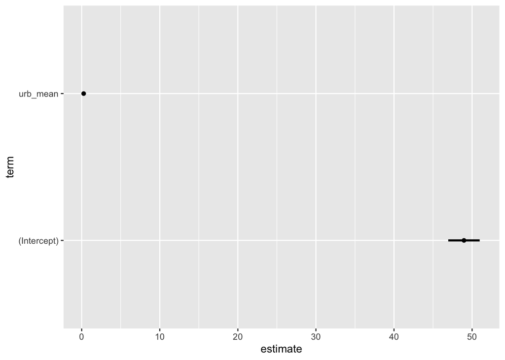

```r
#To calculate the confidence interval, we use 1.96,
#meaning that 95% of the area under a normal curve lies
#within approximately 1.96 standard deviations from the mean
ggplot(results,
      aes(x = estimate, y = term)) +
      geom_point()+
      geom_errorbar(aes(xmin = estimate-1.96*std.error,
                        xmax = estimate+1.96*std.error),
                linewidth = 1, width=0)
```

There is only one issue: the value of the intercept is way too high compared to the value of urbanization. This is why we only see a dot for ubanization and a longer line for the intercept. To fix this problem, we will scale our variables. This means that we substract the mean and divide it by the standard deviation.

```r
model_scaled<-lm(scale(life_exp_mean)~scale(urb_mean), data=merged_data2)
summary(model_scaled)
```

```
Call:
lm(formula = scale(life_exp_mean) ~ scale(urb_mean), data = merged_data2)

Residuals:
     Min       1Q   Median       3Q      Max
-1.62816 -0.44519 -0.05994  0.51680  2.10984

Coefficients:
                  Estimate Std. Error t value Pr(>|t|)
(Intercept)     -3.770e-15  4.955e-02    0.00        1
scale(urb_mean)  6.907e-01  4.967e-02   13.91   <2e-16 ***
---
Signif. codes:  0 '***' 0.001 '**' 0.01 '*' 0.05 '.' 0.1 ' ' 1

Residual standard error: 0.7249 on 212 degrees of freedom
Multiple R-squared:  0.477, Adjusted R-squared:  0.4746
F-statistic: 193.4 on 1 and 212 DF,  p-value: < 2.2e-16
```

Let us now compare the two models.

```r
model1<-lm(life_exp_mean~urb_mean, data=merged_data2)
model2<-lm(scale(life_exp_mean)~scale(urb_mean), data=merged_data2)
models<-list("Unscaled" = model1,
             "Scaled" = model2)

cm <- c('urb_mean'='Urbanization',
        'scale(urb_mean)' = 'Urbanization',
        "(Intercept)"="Intercept")

modelsummary(models, stars = TRUE, coef_map = cm, gof_map = c("nobs", "r.squared"))
```

|  | Unscaled | Scaled |
| --- | --- | --- |
| Urbanization | 0.252*** | 0.691*** |
|  | (0.018) | (0.050) |
| Intercept | 48.961*** | 0.000 |
|  | (1.027) | (0.050) |
| Num.Obs. | 214 | 214 |
| R2 | 0.477 | 0.477 |

+ p < 0.1, * p < 0.05, ** p < 0.01, *** p < 0.001

Let us now try to redraw the coefficients.

```r
#Step1: Save the lm results to a dataframe
model2<-lm(scale(life_exp_mean)~scale(urb_mean), data=merged_data2)
results<-tidy(model2)
```

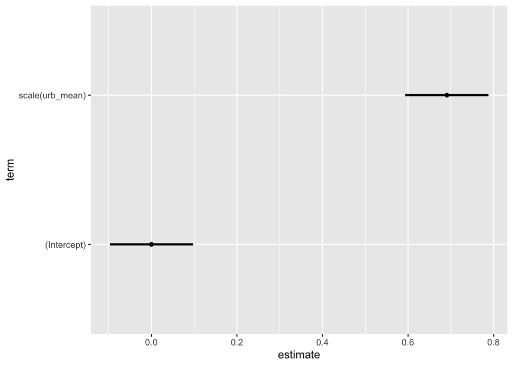

```r
#Step2: Plot the results
ggplot(results, aes(x = estimate, y = term)) +
      geom_point()+
      geom_errorbar(aes(xmin = estimate-1.96*std.error,
                        xmax = estimate+1.96*std.error),
                linewidth = 1, width=0)
```

# 7 Calculating predicted values and residuals

To calculate the predicted values and residuals, we will simply work with our dataframe.

```r
head(merged_data2, n=10)
```

| Entity | Code | life_exp_mean | urb_mean |
| --- | --- | --- | --- |
| Afghanistan | AFG | 45.38333 | 18.61175 |
| Albania | ALB | 68.28611 | 40.44416 |
| Algeria | DZA | 57.53013 | 52.60921 |
| American Samoa | ASM | 68.63750 | 79.76249 |
| Andorra | AND | 77.04861 | 87.04302 |
| Angola | AGO | 45.08466 | 37.53970 |
| Antigua and Barbuda | ATG | 71.20972 | 32.35066 |
| Argentina | ARG | 67.71975 | 85.28215 |
| Armenia | ARM | 67.15694 | 63.11139 |
| Aruba | ABW | 70.25972 | 48.05939 |

We will first add the $\beta_0$ (a) and $\beta_1$ (b) to our dataframe.

```r
merged_data2$b<-model1$coefficients["urb_mean"]
merged_data2$a<-model1$coefficients[1]
head(merged_data2, n=10)
```

| Entity | Code | life_exp_mean | urb_mean | b | a |
| --- | --- | --- | --- | --- | --- |
| Afghanistan | AFG | 45.38333 | 18.61175 | 0.2515915 | 48.96112 |
| Albania | ALB | 68.28611 | 40.44416 | 0.2515915 | 48.96112 |
| Algeria | DZA | 57.53013 | 52.60921 | 0.2515915 | 48.96112 |
| American Samoa | ASM | 68.63750 | 79.76249 | 0.2515915 | 48.96112 |
| Andorra | AND | 77.04861 | 87.04302 | 0.2515915 | 48.96112 |
| Angola | AGO | 45.08466 | 37.53970 | 0.2515915 | 48.96112 |
| Antigua and Barbuda | ATG | 71.20972 | 32.35066 | 0.2515915 | 48.96112 |
| Argentina | ARG | 67.71975 | 85.28215 | 0.2515915 | 48.96112 |
| Armenia | ARM | 67.15694 | 63.11139 | 0.2515915 | 48.96112 |
| Aruba | ABW | 70.25972 | 48.05939 | 0.2515915 | 48.96112 |

Let us now compute the predicted values for life expectancy.

```r
merged_data2$y_hat<-merged_data2$b*merged_data2$urb_mean + merged_data2$a
head(merged_data2, n=10)
```

| Entity | Code | life_exp_mean | urb_mean | b | a | y_hat |
| --- | --- | --- | --- | --- | --- | --- |
| Afghanistan | AFG | 45.38333 | 18.61175 | 0.2515915 | 48.96112 | 53.64368 |
| Albania | ALB | 68.28611 | 40.44416 | 0.2515915 | 48.96112 | 59.13653 |
| Algeria | DZA | 57.53013 | 52.60921 | 0.2515915 | 48.96112 | 62.19715 |
| American Samoa | ASM | 68.63750 | 79.76249 | 0.2515915 | 48.96112 | 69.02868 |
| Andorra | AND | 77.04861 | 87.04302 | 0.2515915 | 48.96112 | 70.86040 |
| Angola | AGO | 45.08466 | 37.53970 | 0.2515915 | 48.96112 | 58.40579 |
| Antigua and Barbuda | ATG | 71.20972 | 32.35066 | 0.2515915 | 48.96112 | 57.10027 |
| Argentina | ARG | 67.71975 | 85.28215 | 0.2515915 | 48.96112 | 70.41738 |
| Armenia | ARM | 67.15694 | 63.11139 | 0.2515915 | 48.96112 | 64.83941 |
| Aruba | ABW | 70.25972 | 48.05939 | 0.2515915 | 48.96112 | 61.05245 |

Let us now plot all the y_hats and ys and let us make the y_hats red triangles. In order to do that, we need to split the sample into two and add them on top of each other. We will have the same x. Y will be Y-hat (predicted Y) and Y (observed Y).

```r
sample1<-subset(merged_data2, select = c(Code, life_exp_mean, urb_mean))
sample1$type<-"Observed"
head(sample1, n=5)
```

| Code | life_exp_mean | urb_mean | type |
| --- | --- | --- | --- |
| AFG | 45.38333 | 18.61175 | Observed |
| ALB | 68.28611 | 40.44416 | Observed |
| DZA | 57.53013 | 52.60921 | Observed |
| ASM | 68.63750 | 79.76249 | Observed |
| AND | 77.04861 | 87.04302 | Observed |

```r
sample2<-subset(merged_data2, select = c(Code, y_hat, urb_mean))
sample2$type<-"Predicted"
names(sample2)[names(sample2)=="y_hat"]<-"life_exp_mean"
head(sample2, n=5)
```

| Code | life_exp_mean | urb_mean | type |
| --- | --- | --- | --- |
| AFG | 53.64368 | 18.61175 | Predicted |
| ALB | 59.13653 | 40.44416 | Predicted |
| DZA | 62.19715 | 52.60921 | Predicted |
| ASM | 69.02868 | 79.76249 | Predicted |
| AND | 70.86040 | 87.04302 | Predicted |

Now we bind the two dataframes by rows. This means that the two dataframes are added (stacked) on top of each other.

```r
sample_both<-rbind(sample1, sample2)
# sort by Code
sample_both <- sample_both[order(sample_both$Code),]
head(sample_both)
```

| Code | life_exp_mean | urb_mean | type |
| --- | --- | --- | --- |
| ABW | 70.25972 | 48.05939 | Observed |
| ABW | 61.05245 | 48.05939 | Predicted |
| AFG | 45.38333 | 18.61175 | Observed |
| AFG | 53.64368 | 18.61175 | Predicted |
| AGO | 45.08466 | 37.53970 | Observed |
| AGO | 58.40579 | 37.53970 | Predicted |

Now, we are ready to make the graph.

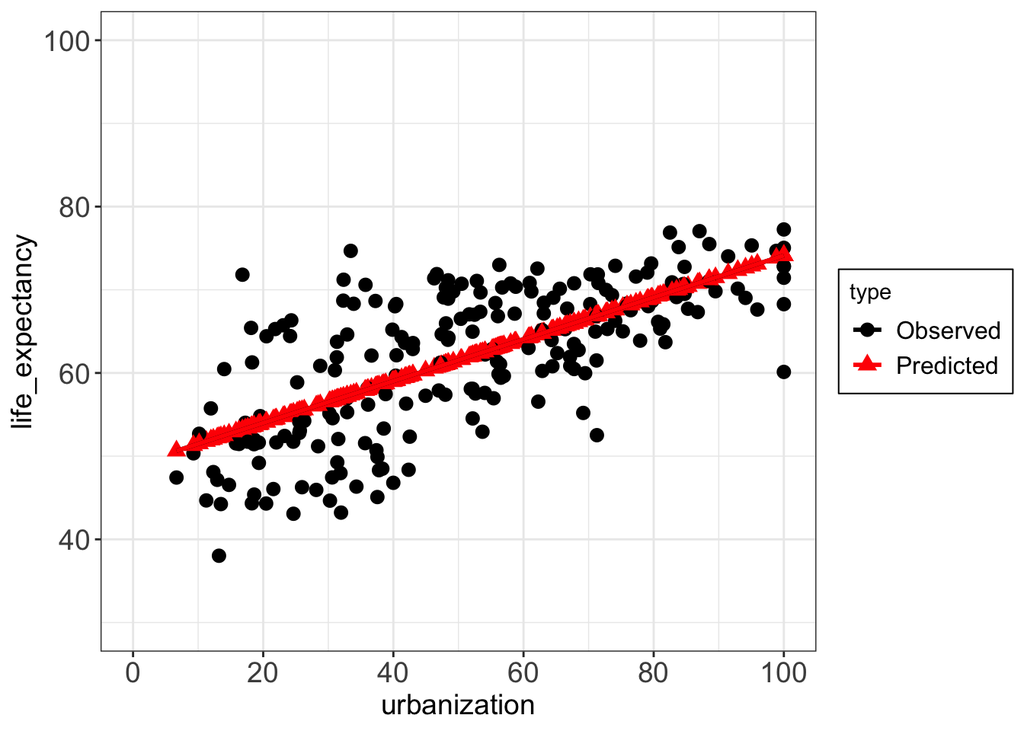

```r
figure1<-ggplot(sample_both, aes(x=urb_mean, y=life_exp_mean,
                                                   color = type, shape=type)) +
  scale_color_manual(values=c('black', "red"))+
  scale_shape_manual(values=c(16, 17))+
  geom_point(size = 3) +
  geom_smooth(method='lm', se=FALSE)+
  theme_bw()+
  scale_x_continuous(name = "urbanization", breaks=seq(0,100,20),
                     limits = c(0,100))+
  scale_y_continuous(name = "life_expectancy", breaks=seq(0,100,20),
                     limits = c(30,100))+
  theme(axis.text.x = element_text(size=14),
        axis.text.y = element_text(size=14),
        axis.title=element_text(size=14),
        plot.title = element_text(hjust = 0.5),
        legend.box.background = element_rect(fill='white'),
        legend.background = element_blank(),
        legend.text=element_text(size=12))
figure1
```

We can now calculate the residuals: residuals are the difference between y_hat and y.

```r
merged_data2$y_resid<-merged_data2$life_exp_mean-merged_data2$y_hat
```

What are the countries that deviate the most from our prediction? Let’s say that we want to emphasize in a scatter plot the 4th quartile countries that deviate the most from our prediction. To do that we go back to our merged dataset. Note that the residuals can be both positive and negative, which is why we take the absolute value.

```r
summary(abs(merged_data2$y_resid))
```

```
     Min.   1st Qu.    Median      Mean   3rd Qu.      Max.
 0.001473  2.186840  4.077296  5.115602  7.644769 18.622716
```

We can now create a new variables in the dataset that captures whether countries are in that upper quartile deviation.

```r
#Creating a variable that has "normal" as values
merged_data2$deviation<-"normal"
#Create threshold for deviation
threshold<-summary(abs(merged_data2$y_resid))[5]
#Changing the "normal" to "high" if the residual is higher than a specific value
merged_data2$deviation[abs(merged_data2$y_resid)>threshold]<-"high"
#Creating a new variable - "name_deviation" to indicate the name of the countries which deviate
merged_data2$name_deviation[abs(merged_data2$y_resid)>threshold]<-merged_data2$Entity
#Examinging the first 7 entries
head(merged_data2, n=7)
```

| Entity | Code | life_exp_mean | urb_mean | b | a | y_hat | y_resid | deviation | name_deviation |
| --- | --- | --- | --- | --- | --- | --- | --- | --- | --- |
| Afghanistan | AFG | 45.38333 | 18.61175 | 0.2515915 | 48.96112 | 53.64368 | -8.2603428 | high | Afghanistan |
| Albania | ALB | 68.28611 | 40.44416 | 0.2515915 | 48.96112 | 59.13653 | 9.1495859 | high | Albania |
| Algeria | DZA | 57.53013 | 52.60921 | 0.2515915 | 48.96112 | 62.19715 | -4.6670150 | normal | NA |
| American Samoa | ASM | 68.63750 | 79.76249 | 0.2515915 | 48.96112 | 69.02868 | -0.3911827 | normal | NA |
| Andorra | AND | 77.04861 | 87.04302 | 0.2515915 | 48.96112 | 70.86040 | 6.1882101 | normal | NA |
| Angola | AGO | 45.08466 | 37.53970 | 0.2515915 | 48.96112 | 58.40579 | -13.3211304 | high | Algeria |
| Antigua and Barbuda | ATG | 71.20972 | 32.35066 | 0.2515915 | 48.96112 | 57.10027 | 14.1094550 | high | American Samoa |

We can now plot to see those deviations

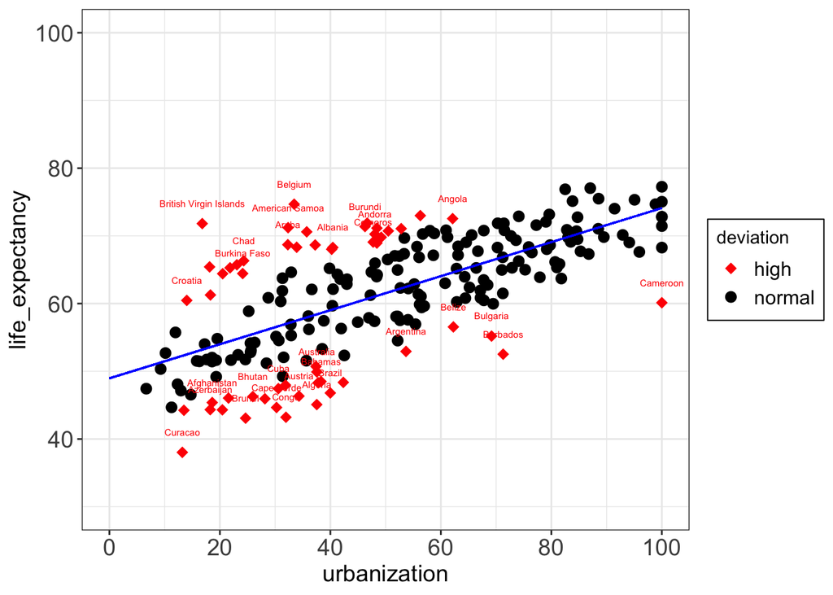

```r
ggplot(merged_data2, aes(x=urb_mean, y=life_exp_mean,
                                                   color = deviation, shape=deviation)) +
  scale_color_manual(values=c('red', "black"))+
  scale_shape_manual(values=c(18, 16))+
  geom_point(size = 3) +
  #Plotting the regression line
  geom_segment(aes(x = 0, y = model1$coefficients[1],
                   xend = 100,
                   yend = model1$coefficients[["urb_mean"]] * max(merged_data2$urb_mean) +model1$coefficients[1]), color = "blue")+
  #Adding the name of the country deviations
  geom_text(aes(label = name_deviation),
              size = 2,
              check_overlap = TRUE, position = position_nudge(y = 3))+
  theme_bw()+
  scale_x_continuous(name = "urbanization", breaks=seq(0,100,20),
                     limits = c(0,100))+
  scale_y_continuous(name = "life_expectancy", breaks=seq(0,100,20),
                     limits = c(30,100))+
  theme(axis.text.x = element_text(size=14),
        axis.text.y = element_text(size=14),
        axis.title=element_text(size=14),
        plot.title = element_text(hjust = 0.5),
        legend.box.background = element_rect(fill='white'),
        legend.background = element_blank(),
        legend.text=element_text(size=12))
```

# 8 Urbanization and life expectancy over time

Up until now, we took the average for both urbanization and life expectancy and we worked very little with the values of these two variables over time.

Let us examine the relationship between life expectancy and urbanization in 1970, 1990, 2000, and 2020

We first go back to our unaveraged datasets. We first clean them.

```r
#Removing the countries that have no CODE
life_expectancy_df2<-subset(life_expectancy_df, life_expectancy_df$Code!="")
urbanization_df2<-subset(urbanization_df, urbanization_df$Code!="")
#Renaming variable
names(life_expectancy_df2)[4]<-"life_exp_yearly"
names(urbanization_df2)[4]<-"urb_yearly"
#Removing "Entity" from urbanization_df2
urbanization_df2<-subset(urbanization_df2, select =-c(Entity))
```

We now join them based on Code and Year.

```r
merged_df_year<-left_join(life_expectancy_df2, urbanization_df2, by = c("Code"="Code", "Year"="Year"))
```

Let us now select the relevant years and plot them.

```r
merged_1970<-subset(merged_df_year, Year==1970)
merged_1990<-subset(merged_df_year, Year==1990)
merged_2000<-subset(merged_df_year, Year==2000)
merged_2020<-subset(merged_df_year, Year==2020)
```

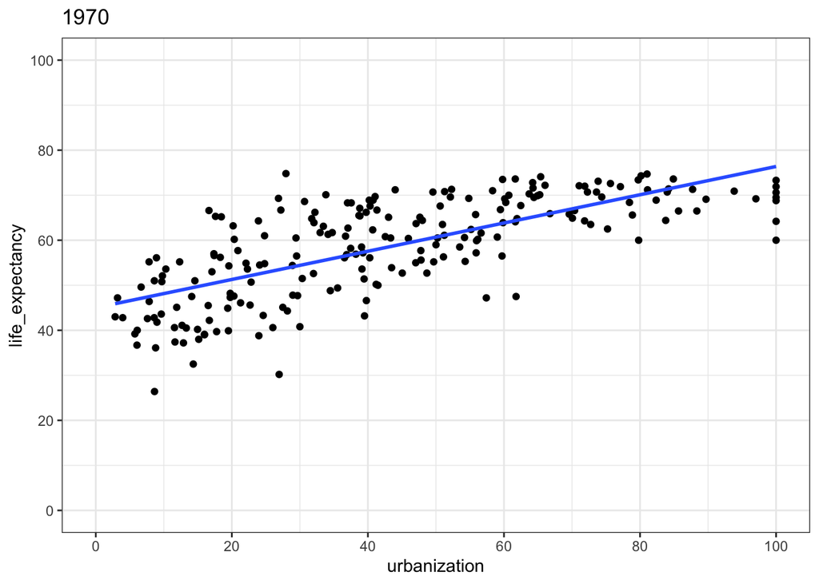

```r
ggplot(merged_1970, aes(x=urb_yearly, y=life_exp_yearly)) +
  geom_point()+
  scale_x_continuous(name = "urbanization", breaks=seq(0,100,20),
                     limits = c(0,100))+
  scale_y_continuous(name = "life_expectancy", breaks=seq(0,100,20),
                     limits = c(0,100))+
  geom_smooth(method = "lm", se = FALSE)+
  ggtitle("1970")+
  theme_bw()
```

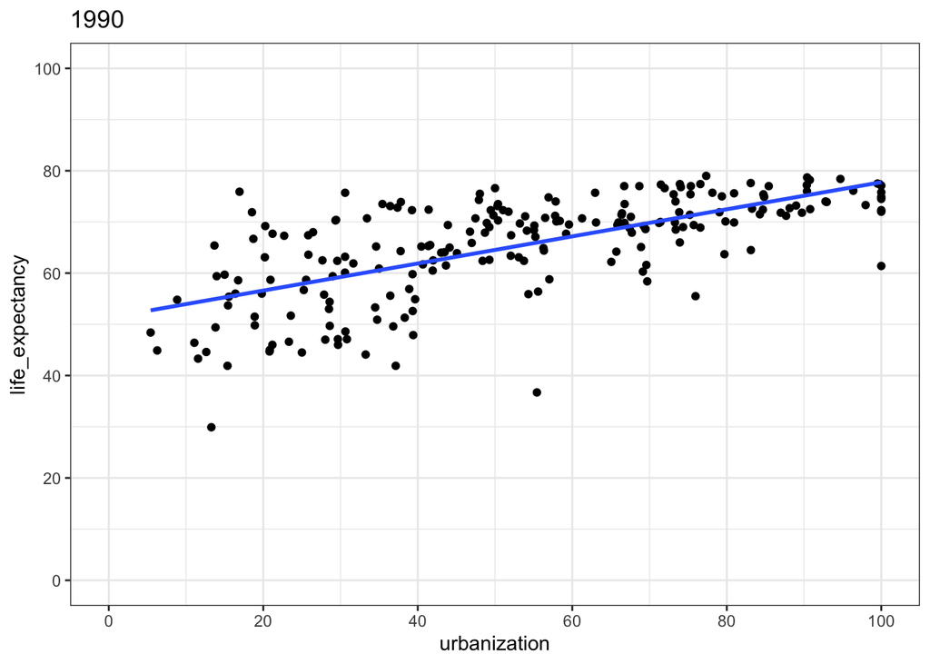

```r
ggplot(merged_1990, aes(x=urb_yearly, y=life_exp_yearly)) +
  geom_point()+
  scale_x_continuous(name = "urbanization", breaks=seq(0,100,20),
                     limits = c(0,100))+
  scale_y_continuous(name = "life_expectancy", breaks=seq(0,100,20),
                     limits = c(0,100))+
  geom_smooth(method = "lm", se = FALSE)+
  ggtitle("1990")+
  theme_bw()
```

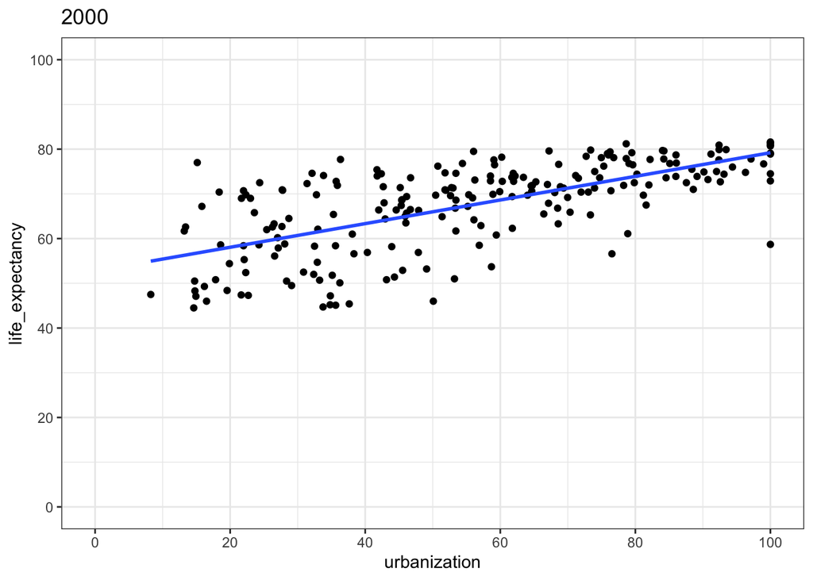

```r
ggplot(merged_2000, aes(x=urb_yearly, y=life_exp_yearly)) +
  geom_point()+
  scale_x_continuous(name = "urbanization", breaks=seq(0,100,20),
                     limits = c(0,100))+
  scale_y_continuous(name = "life_expectancy", breaks=seq(0,100,20),
                     limits = c(0,100))+
  geom_smooth(method = "lm", se = FALSE)+
  ggtitle("2000")+
  theme_bw()
```

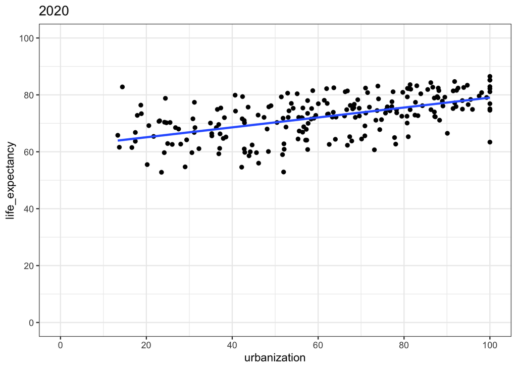

```r
ggplot(merged_2020, aes(x=urb_yearly, y=life_exp_yearly)) +
  geom_point()+
  scale_x_continuous(name = "urbanization", breaks=seq(0,100,20),
                     limits = c(0,100))+
  scale_y_continuous(name = "life_expectancy", breaks=seq(0,100,20),
                     limits = c(0,100))+
  geom_smooth(method = "lm", se = FALSE)+
  ggtitle("2020")+
  theme_bw()
```

What can we say about the relationship between urbanization and life expectancy over time? It seems that it flattens out. But what if we created more graphs that shows this over time. We can create a gif that allows us to see the evolution of the relationship between urbanization and life expectancy over time.

[figure not shown]

```r
library(gganimate)
library(gifski)
library(av)
library(magick)

merged_year_1950on<-subset(merged_df_year, Year>1950)
# Create the base plot
figure_animated <- ggplot(merged_year_1950on, mapping = aes(x = urb_yearly, y = life_exp_yearly)) +
  geom_point() +
  theme_bw() +
  geom_smooth(method = "lm", se = FALSE) +
  scale_x_continuous(breaks = seq(0, 100, by = 20), limits = c(0, 100)) +
  scale_y_continuous(breaks = seq(0, 100, by = 20), limits = c(0, 100)) +
  labs(title = 'Year: {frame_time}', x = 'urbanization', y = 'life expectancy')

# Create the animation
animation <- figure_animated +
  transition_states(Year) +
  transition_time(as.integer(Year))

# Animate the plot
animate(animation, height = 400, width = 600, fps = 4,
        renderer = gifski_renderer())
```

The animation really allows us to see that countries become more urbanized over time and as a result, the relationship between urbanization and life expectancy flattens out.